# AA_BUBBLES

## BUBBLE SORT

Bubble Sort adalah sebuah algoritma yang mengurutkan sebuah array dari nilai terkecil ke nilai terbesar.

Bubble Sort adalah algoritma sorting paling sederhana yang bekerja dengan cara melakukan swap berulang pada elemen yang bersebelahan (adjacent elements) jika urutannya salah.

Algoritma ini tidak efisien untuk data set besar karena average dan worst-case time complexity-nya cukup tinggi.

Sebelum di bubble sort

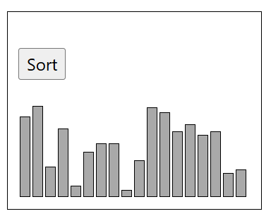

Sesudah di bubble sort

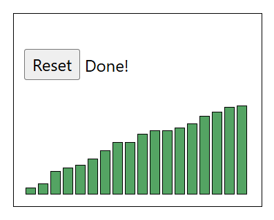

Jalankan simulasi untuk melihat bagaimana algoritma Bubble Sort mengurutkan sebuah array nilai. Setiap nilai dalam array direpresentasikan sebagai sebuah kolom.

Kata "Bubble" berasal dari cara kerja algoritma ini, yaitu membuat nilai terbesar “mengapung ke atas” (bubble up).

Cara kerja:

1. Telusuri array, satu nilai setiap waktu.
2. Untuk setiap nilai, bandingkan dengan nilai berikutnya.
3. Jika nilai lebih besar dari nilai berikutnya, lakukan swap agar nilai terbesar berada di belakang.
4. Ulangi proses ini sebanyak jumlah nilai dalam array.

### Manual Run Through

Sebelum kita mengimplementasikan algoritma Bubble Sort dalam bahasa pemrograman, mari kita coba secara manual satu kali untuk memahami konsepnya.

Langkah 1: Kita mulai dengan unsorted array.

```
[7, 12, 9, 11, 3]
```

Langkah 2: Bandingkan dua nilai pertama. Apakah nilai terkecil sudah di depan? Ya → tidak perlu swap.

```
[7, 12, 9, 11, 3]
```

Langkah 3: Geser satu langkah, bandingkan 12 dan 9. Apakah nilai terkecil di depan? Tidak.

```
[7, 12, 9, 11, 3]
```

Langkah 4: Lakukan swap agar 9 di depan.

```
[7, 9, 12, 11, 3]
```

Langkah 5: Geser lagi, bandingkan 12 dan 11.

```
[7, 9, 12, 11, 3]
```

Langkah 6: Harus swap agar 11 sebelum 12.

```
[7, 9, 11, 12, 3]
```

Langkah 7: Bandingkan 12 dan 3, perlu swap? Ya.

```
[7, 9, 11, 12, 3]
```

Langkah 8: Swap sehingga 3 di depan.

```
[7, 9, 11, 3, 12]
```

Ulangi sampai tidak diperlukan lagi swap dan Anda akan mendapatkan array yang terurut

Sebelum diurutkan

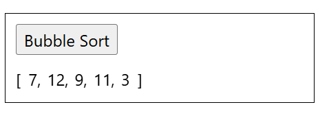

Sesudah diurutkan

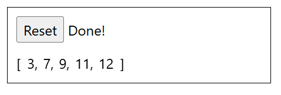

### Ciri-Ciri Bubble Sort

1. Membandingkan Elemen Berdekatan

Bubble Sort hanya membandingkan data yang posisinya bersebelahan.

2. Menggunakan Pertukaran (Swap)

Jika urutan salah maka elemen ditukar.

3. Proses Berulang

Proses dilakukan terus sampai data terurut.

4. Mudah Dipahami

Algoritma ini sangat cocok untuk pemula.

### Struktur Dasar Bubble Sort

Bubble Sort biasanya menggunakan:

- Perulangan luar (outer loop)
- Perulangan dalam (inner loop)

### Implement Bubble Sort dalam Python

Untuk mengimplementasikan algoritma Bubble Sort dalam Python, kita membutuhkan:

1. Sebuah array berisi nilai yang akan diurutkan.
2. Inner loop yang menelusuri array dan melakukan swap jika nilai pertama lebih besar dari nilai berikutnya. Loop ini berkurang satu setiap iterasi.
3. Outer loop yang mengatur berapa kali inner loop dijalankan. Untuk array dengan n nilai, loop ini berjalan n-1 kali.

Contoh:

```python
mylist = [64, 34, 25, 12, 22, 11, 90, 5]

n = len(mylist)
for i in range(n-1):
  for j in range(n-i-1):
    if mylist[j] > mylist[j+1]:
      mylist[j], mylist[j+1] = mylist[j+1], mylist[j]

print(mylist)
```

```
[5, 11, 12, 22, 25, 34, 64, 90]
```

Contoh lain:

```python
# Optimized Python program for implementation of Bubble Sort
def bubbleSort(arr):
    n = len(arr)

    # Traverse through all array elements
    for i in range(n):
        swapped = False

        # Last i elements are already in place
        for j in range(0, n-i-1):

            # Traverse the array from 0 to n-i-1
            # Swap jika elemen lebih besar dari elemen berikutnya
            if arr[j] > arr[j+1]:
                arr[j], arr[j+1] = arr[j+1], arr[j]
                swapped = True

        if (swapped == False):
            break

# Driver code untuk testing
if __name__ == "__main__":
    arr = [64, 34, 25, 12, 22, 11, 90]

    bubbleSort(arr)

    print("Sorted array:")
    for i in range(len(arr)):
        print("%d" % arr[i], end=" ")
```

```
Sorted array:
11 12 22 25 34 64 90
```

### Bubble Sort Ascending

Ascending berarti dari kecil ke besar.

Contoh:

```
[1, 2, 3, 4, 5]
```

kode

```python
data = [9, 3, 7, 1]

for i in range(len(data)):
    for j in range(len(data)-1):

        if data[j] > data[j+1]:
            data[j], data[j+1] = data[j+1], data[j]

print(data)
```

```
[1, 3, 7, 9]
```

### Bubble Sort Descending

Descending berarti dari besar ke kecil.

Contoh:

```
[9, 7, 5, 3, 1]
```

Kode:

```python
data = [9, 3, 7, 1]

for i in range(len(data)):
    for j in range(len(data)-1):

        if data[j] < data[j+1]:
            data[j], data[j+1] = data[j+1], data[j]

print(data)
```

```
[9, 7, 3, 1]
```

### Bubble Sort Improvement

Algoritma Bubble Sort masih bisa ditingkatkan.

Bayangkan arraynya sudah hampir terurut, dengan angka terendah di awal, seperti ini misalnya:

```
mylist = [7, 3, 9, 12, 11]
```

Dalam kasus ini, sebenarnya array sudah terurut setelah satu kali loop, tetapi algoritma tetap berjalan tanpa melakukan swap, yang sebenarnya tidak perlu.

Jika algoritma melewati array satu kali tanpa menukar nilai apa pun, array harus selesai diurutkan, dan kita dapat menghentikan algoritma, seperti ini:

Contoh

Improved Bubble Sort:

```python
mylist = [7, 3, 9, 12, 11]

n = len(mylist)
for i in range(n-1):
  swapped = False
  for j in range(n-i-1):
    if mylist[j] > mylist[j+1]:
      mylist[j], mylist[j+1] = mylist[j+1], mylist[j]
      swapped = True
  if not swapped:
    break

print(mylist)
```

```
[3, 7, 9, 11, 12]
```

### Optimasi Bubble Sort

Bubble Sort dapat dioptimalkan menggunakan variabel penanda (flag).

Jika dalam satu iterasi tidak ada pertukaran, maka data sudah terurut.

Contoh

```python
data = [1, 2, 3, 4, 5]

n = len(data)

for i in range(n):

    tukar = False

    for j in range(0, n-i-1):

        if data[j] > data[j+1]:
            data[j], data[j+1] = data[j+1], data[j]
            tukar = True

    if not tukar:
        break

print(data)
```

```
[1, 2, 3, 4, 5]
```

### Bubble Sort Time Complexity

1. Best Case

   ```
   O(n)
   ```

Terjadi jika data sudah terurut.

2. Average Case

   ```
   O(n²)
   ```

3. Worst Case

   ```
   O(n²)
   ```

Terjadi jika data terurut terbalik

Algoritma Bubble Sort melakukan perulangan untuk setiap nilai dalam array, lalu membandingkannya dengan nilai di sebelahnya. Untuk array dengan n nilai, Dalam satu loop ada sekitar n perbandingan. Proses ini diulang sebanyak n kali.

Sehingga total perbandingan adalah n × n Maka

```
Time Complexity: O(n2)
Auxiliary Space: O(1)
```

Grafik yang menggambarkan kompleksitas waktu Bubble Sort terlihat seperti ini:

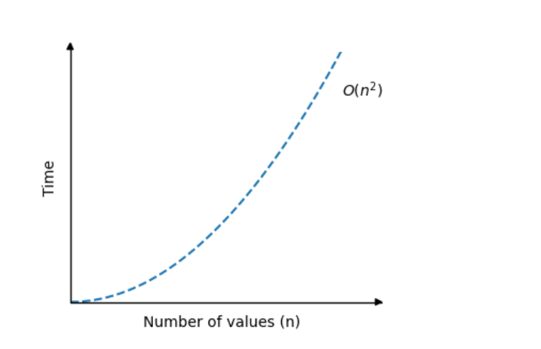

Seperti yang Anda lihat, waktu proses meningkat sangat cepat ketika ukuran array ditingkatkan.

#### Advantages of Bubble Sort:

- Mudah dipahami dan diimplementasikan.
- Tidak membutuhkan memory tambahan.
- Termasuk stable sorting algorithm, artinya elemen dengan nilai yang sama tetap mempertahankan urutan relatifnya.

#### Disadvantages of Bubble Sort:

- Memiliki time complexity O(n²), sehingga sangat lambat untuk data set besar.
- Hampir tidak memiliki atau sangat terbatas dalam penggunaan di dunia nyata. Biasanya hanya digunakan dalam pembelajaran (academic purposes) untuk memahami konsep sorting.

### Quiz GFG:

1. Berapakah kompleksitas waktu terbaik dari algoritma bubble sort (yang dioptimalkan)?

   0(N)
2. Misalkan kita menggunakan Bubble Sort untuk mengurutkan n elemen berbeda dalam urutan menaik. Kapan kasus terbaik dari Bubble Sort terjadi?

   Ketika elemen diurutkan dalam urutan menaik
3. Jumlah pertukaran yang dibutuhkan untuk mengurutkan angka 8, 22, 7, 9, 31, 5, 13 dalam urutan naik, menggunakan bubble sort adalah

   10
4. Berapakah jumlah maksimum perbandingan yang dapat dilakukan ketika algoritma bubble sort diimplementasikan? Misalkan terdapat n elemen dalam array.

   (n*(n-1))/2
5. Berapakah kompleksitas waktu terburuk dari algoritma Bubble sort?

   O(N^2)
6. Bubble Sort adalah contoh dari algoritma pengurutan _______.

   Berdasarkan perbandingan
7. Bubble Sort adalah contoh algoritma pengurutan yang:

   Menukar elemen yang berdekatan secara langsung
8. Manakah dari pernyataan berikut yang benar mengenai Bubble Sort?

   Ini adalah algoritma pengurutan di tempat (in-place sorting).
9. Dalam Bubble Sort, setelah setiap putaran, elemen terbesar di antara elemen yang belum diurutkan akan "naik" ke posisi mana? Anda dapat berasumsi bahwa elemen-elemen tersebut diurutkan dalam urutan menaik.

   Terakhir
10. Apa kelemahan utama dari algoritma Bubble Sort?

    Proses ini memiliki kompleksitas waktu yang tinggi.